# Ultrasound-diagnosed fatty liver in a Japanese health-check cohort

Dataset 9: Liver enzymes and arterial stiffness in a Japanese health-check cohort

RSR feasibility analysis

2026-08-03

# Introduction

A general health-check programme in Japan enrolled 912 men and women aged 24 to 84 years and combined abdominal ultrasound, a fasting blood panel and automated vascular measurements in a single visit; the cohort is reported in *BMJ Open* 2014;4:e005413. Fatty liver was present on ultrasound in 265 (29.1%) of those scanned. Non-alcoholic fatty liver disease is now the commonest chronic liver condition in high-income countries and is a marker of insulin resistance as much as of liver injury, so knowing which routinely measured characteristics identify it at a health check is directly useful for triage.

**Aim.** Among these health-check attendees, we examined which of age, sex, body mass index, systolic blood pressure, smoking status, alcohol intake, regular exercise, fasting glucose, triglycerides, HDL cholesterol, kidney function and log2 gamma-GT are independently associated with ultrasound-diagnosed fatty liver, mutually adjusting for the others.

This is a *Purpose 3* analysis: several predictors are of interest and the question is which remain associated with the outcome after mutual adjustment.

# Methods

**Data source.** A cross-sectional Japanese health-check cohort of 912 adults attending a voluntary medical check-up programme that included abdominal ultrasound, a fasting blood panel and automated measurement of pulse-wave velocity and the ankle-brachial index.

**Variables.** The outcome is `fatty_liver`, a binary indicator where the **event is fatty liver visible on abdominal ultrasound** (265 events among the 911 participants scanned). Predictors are age (years), sex (reference Male, the larger group at 592 of 912), BMI (kg/m2), systolic blood pressure (mmHg), smoking status (three levels, reference Never, the largest group at 461), alcohol intake (g/week), regular exercise (reference No, the unexposed and larger group), fasting glucose (mg/dL), triglycerides (mg/dL), HDL cholesterol (mg/dL), estimated glomerular filtration rate (mL/min/1.73m2) and gamma-GT on a log2 scale, so that a one-unit increase is a doubling of GGT.

**The predictor set was cut from 18 to 12 before any model was fitted.** The events budget alone would not have forced this: with 253 events, the conventional ten-events-per-parameter rule supports about 25 parameters, and all 18 predictors would cost only 19. The cut was made instead for **redundancy** and **interpretability**. The suggested list contains three sets of near-duplicates. Systolic and diastolic pressure correlate at r = 0.90 (VIFs 5.1 and 5.3 with both in the model). The four lipid measures satisfy the Friedewald identity total = LDL + HDL + triglycerides/5 to within rounding: regressing total cholesterol on the other three gives R-squared 0.955 with coefficients 1.00, 1.06 and 0.17, and with all four in the model the VIFs reach 24.7 (total cholesterol) and 20.1 (LDL). ALT, AST and gamma-GT are the third set (ALT-AST r = 0.78). We therefore kept systolic pressure in place of both pressures; HDL cholesterol and triglycerides, the two metabolic-syndrome lipid components, in place of all four lipids; and log2 gamma-GT, the enzyme of interest in the source paper, in place of all three enzymes. Uric acid was dropped because it duplicates information already carried by adiposity and kidney function (r = -0.30 with eGFR, r = 0.38 with BMI). Beyond the statistics, a table of 18 mutually adjusted odds ratios cannot be read as an answer to “which predictors survive adjustment”, which is the question here.

**Statistical analysis.** `glm(family = binomial)`, justified because the outcome is binary. We fitted a univariable model for each predictor first, then a single multivariable model containing all of them. Predictors were chosen in advance on subject-matter grounds, not by significance. Coefficients are exponentiated and reported as odds ratios with 95% confidence intervals; significance threshold 0.05. Model adequacy was assessed with `performance::check_model()`, focusing on binned residuals, collinearity, influential observations and events per parameter. Analysis used R version 4.6.0 (2026-04-24) with tidyverse, gtsummary and performance.

**Missing data.** Complete-case analysis: 882 of 912 rows were analysed (30 dropped), leaving **253 events**. The outcome itself is missing for 1 participant; the rest of the loss is `regular_exercise` (16 missing) and `alcohol_g_per_week` (13 missing), which do not overlap. Only 844 of 912 rows are complete on *every* column in the file.

# Results

## Sample characteristics

**Table 1. Sample characteristics by fatty-liver status.**

| **Characteristic** | **N** | **No fatty liver** N = 629<sup>1</sup> | **Fatty liver** N = 253<sup>1</sup> |
| --- | --- | --- | --- |
| Age (years) | 882 | 52 (45, 59) | 51 (43, 57) |
| Sex | 882 |  |  |
| Male |  | 365 (58%) | 211 (83%) |
| Female |  | 264 (42%) | 42 (17%) |
| BMI (kg/m2) | 882 | 22.11 (20.35, 23.53) | 25.62 (23.74, 27.09) |
| Systolic BP (mmHg) | 882 | 117 (107, 127) | 127 (118, 136) |
| Smoking status | 882 |  |  |
| Never |  | 337 (54%) | 108 (43%) |
| Former |  | 166 (26%) | 80 (32%) |
| Current |  | 126 (20%) | 65 (26%) |
| Alcohol (g/week) | 882 | 3 (0, 90) | 6 (0, 110) |
| Takes regular exercise | 882 | 146 (23%) | 31 (12%) |
| Fasting glucose (mg/dL) | 882 | 94 (89, 100) | 101 (95, 108) |
| Triglycerides (mg/dL) | 882 | 68 (48, 101) | 121 (82, 174) |
| HDL cholesterol (mg/dL) | 882 | 56 (47, 66) | 44 (38, 52) |
| eGFR (mL/min/1.73m2) | 882 | 70 (63, 78) | 68 (60, 77) |
| Gamma-GT (log2 U/L) | 882 | 4.09 (3.70, 4.58) | 4.58 (4.17, 5.21) |

<sup>1</sup> Median (Q1, Q3); n (%)

Participants with fatty liver are markedly heavier (median BMI 25.6 versus 22.1 kg/m2), have higher gamma-GT (median 4.58 versus 4.09 on the log2 scale, i.e. about 1.4-fold higher on the raw scale), higher fasting glucose and triglycerides and lower HDL cholesterol. They are overwhelmingly male (83% versus 58%), and their median age is essentially the same as the unaffected group, which is already a clue that this is a metabolic rather than a degenerative condition.

## Exploratory figure

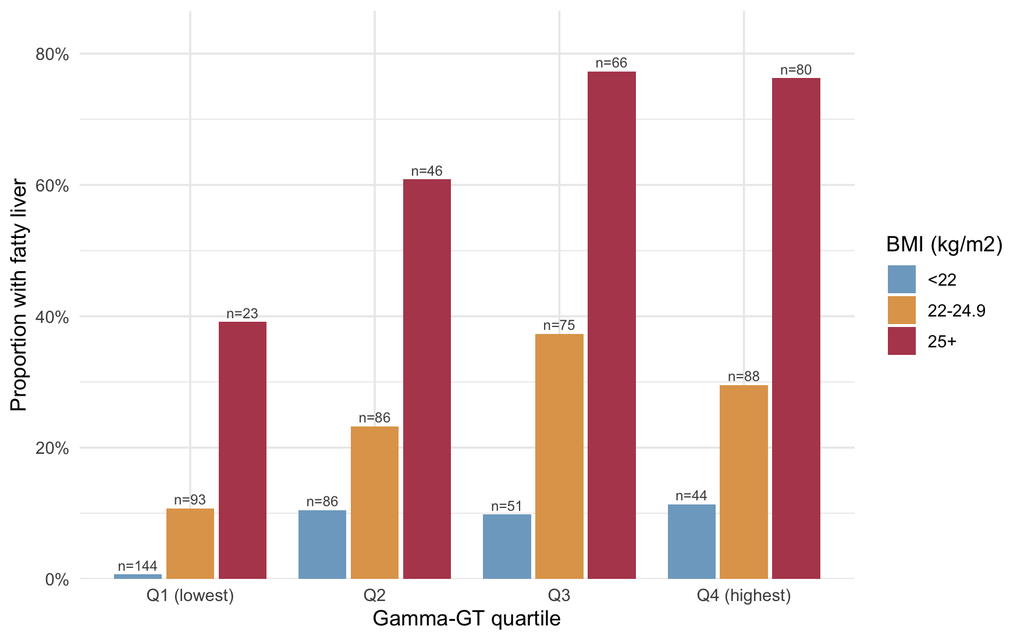

Figure 1. Proportion with ultrasound fatty liver by gamma-GT quartile and BMI category.

## Univariable models

| **Characteristic** | **N** | **OR** | **95% CI** | **p-value** |
| --- | --- | --- | --- | --- |
| Age (years) | 882 | 0.99 | 0.97, 1.00 | 0.12 |
| Sex | 882 |  |  |  |
| Male |  | — | — |  |
| Female |  | 0.28 | 0.19, 0.39 | <0.001 |
| BMI (kg/m2) | 882 | 1.69 | 1.56, 1.83 | <0.001 |
| Systolic BP (mmHg) | 882 | 1.05 | 1.03, 1.06 | <0.001 |
| Smoking status | 882 |  |  |  |
| Never |  | — | — |  |
| Former |  | 1.50 | 1.07, 2.12 | 0.020 |
| Current |  | 1.61 | 1.11, 2.33 | 0.012 |
| Alcohol (g/week) | 882 | 1.00 | 1.00, 1.00 | 0.7 |
| Takes regular exercise | 882 |  |  |  |
| No |  | — | — |  |
| Yes |  | 0.46 | 0.30, 0.69 | <0.001 |
| Fasting glucose (mg/dL) | 882 | 1.08 | 1.06, 1.09 | <0.001 |
| Triglycerides (mg/dL) | 882 | 1.01 | 1.01, 1.01 | <0.001 |
| HDL cholesterol (mg/dL) | 882 | 0.94 | 0.92, 0.95 | <0.001 |
| eGFR (mL/min/1.73m2) | 882 | 0.99 | 0.97, 1.00 | 0.028 |
| Gamma-GT (log2 U/L) | 882 | 2.11 | 1.76, 2.54 | <0.001 |

Abbreviations: CI = Confidence Interval, OR = Odds Ratio

BMI is the strongest crude predictor by a wide margin: each additional kg/m2 multiplies the odds of fatty liver by OR 1.69 (95% CI 1.56 to 1.83) (p <0.001), which compounds to about 13.7-fold per 5 kg/m2. Each doubling of gamma-GT multiplies the odds by OR 2.11 (95% CI 1.76 to 2.54) (p <0.001). Women have OR 0.28 (95% CI 0.19 to 0.39) the odds of men (p <0.001), a nearly four-fold male excess. The metabolic panel behaves as expected: fasting glucose OR 1.08 (95% CI 1.06 to 1.09) per mg/dL (p <0.001), triglycerides OR 1.0106 (95% CI 1.0082 to 1.0132) per mg/dL (p <0.001, i.e. about 1.70-fold per 50 mg/dL), HDL cholesterol OR 0.94 (95% CI 0.92 to 0.95) per mg/dL (p <0.001), and systolic pressure OR 1.05 (95% CI 1.03 to 1.06) per mmHg (p <0.001). Regular exercise is associated with OR 0.46 (95% CI 0.30 to 0.69) (p <0.001), and both former (OR 1.50 (95% CI 1.07 to 2.12), p = 0.020) and current smoking (OR 1.61 (95% CI 1.11 to 2.33), p = 0.012) with raised odds. Two predictors show no crude association at all: age (OR 0.99 (95% CI 0.97 to 1.00), p = 0.120) and - strikingly, for a liver outcome - alcohol intake (OR 1.0002 (95% CI 0.9991 to 1.0013), p = 0.713).

## Why adjustment is needed

**Sex** confounds the gamma-GT association hard. Men have roughly 1.5 times the GGT of women on the raw scale (medians 4.39 versus 3.81 on the log2 scale) and, independently of GGT, roughly four times the crude odds of fatty liver, so part of any apparent GGT effect is simply a male effect. **BMI** is the second, and it confounds nearly everything else in the list: heavier attendees have higher GGT (r = 0.28), higher triglycerides (r = 0.28), lower HDL (r = -0.31), higher blood pressure and higher glucose, and adiposity is the dominant cause of hepatic steatosis. Any crude lipid, pressure or enzyme association is therefore partly a body-mass association. **Alcohol** matters for the opposite reason. Drinking here is almost a proxy for being male (78% of men report any alcohol against 49% of women) and it is strongly associated with GGT (r = 0.33) and with triglycerides (r = 0.20). Being male and having high GGT both raise the odds of fatty liver sharply, so those two push the crude alcohol coefficient upward and cancel whatever the drinking itself is doing. Within men alone the pattern is already visible: 40% of male non-drinkers have fatty liver against 36% of male drinkers. Mutual adjustment lets each odds ratio be read as a comparison between attendees of the same age, sex, body mass, pressure, smoking, drinking, activity and metabolic profile.

## Multivariable model

| **Characteristic** | **OR** | **95% CI** | **p-value** |
| --- | --- | --- | --- |
| Age (years) | 0.99 | 0.97, 1.02 | 0.6 |
| Sex |  |  |  |
| Male | — | — |  |
| Female | 0.52 | 0.28, 0.94 | 0.032 |
| BMI (kg/m2) | 1.55 | 1.42, 1.70 | <0.001 |
| Systolic BP (mmHg) | 1.01 | 1.00, 1.03 | 0.056 |
| Smoking status |  |  |  |
| Never | — | — |  |
| Former | 0.70 | 0.42, 1.16 | 0.2 |
| Current | 0.80 | 0.46, 1.37 | 0.4 |
| Alcohol (g/week) | 1.00 | 1.00, 1.00 | 0.013 |
| Takes regular exercise |  |  |  |
| No | — | — |  |
| Yes | 0.59 | 0.34, 1.00 | 0.054 |
| Fasting glucose (mg/dL) | 1.05 | 1.03, 1.08 | <0.001 |
| Triglycerides (mg/dL) | 1.00 | 1.00, 1.00 | 0.2 |
| HDL cholesterol (mg/dL) | 0.97 | 0.95, 0.98 | <0.001 |
| eGFR (mL/min/1.73m2) | 1.01 | 0.99, 1.03 | 0.3 |
| Gamma-GT (log2 U/L) | 1.31 | 1.01, 1.70 | 0.044 |

Abbreviations: CI = Confidence Interval, OR = Odds Ratio

**Model fit: multivariable logistic model for fatty liver**

| Statistic | Value |
| --- | --- |
| Complete-case N | 882 |
| Events (fatty liver = 1) | 253 |
| Parameters (excl. intercept) | 13 |
| Events per parameter | 19.5 |
| AIC (null model) | 1059.2 |
| AIC (full model) | 684.9 |
| Tjur's R-squared | 0.422 |

The model has 253 events for 13 estimated parameters, i.e. **19.5 events per parameter**, comfortably clear of the conventional minimum of ten. AIC falls from 1059.2 for the intercept-only model to 684.9, a drop of 374.3, and Tjur’s R-squared is 0.422 - a genuinely well-discriminating model by the standards of observational epidemiology.

Among attendees of the same age, sex, blood pressure, smoking, drinking, exercise, glucose, lipids, kidney function and gamma-GT, each additional kg/m2 of BMI multiplies the odds of fatty liver by OR 1.55 (95% CI 1.42 to 1.70) (p <0.001), about 9.0-fold per 5 kg/m2. Among attendees alike on everything else, each additional mg/dL of fasting glucose multiplies the odds by OR 1.05 (95% CI 1.03 to 1.08) (p <0.001) and each additional mg/dL of HDL cholesterol by OR 0.97 (95% CI 0.95 to 0.98) (p <0.001), i.e. about 0.71-fold per 10 mg/dL of HDL. Women retain OR 0.52 (95% CI 0.28 to 0.94) the odds of men (p = 0.032).

Two coefficients are worth dwelling on. **Gamma-GT survives, but barely**: each doubling gives OR 1.31 (95% CI 1.01 to 1.70) (p = 0.044), against a crude OR 2.11 (95% CI 1.76 to 2.54). **Alcohol becomes protective**: OR 0.9979 (95% CI 0.9963 to 0.9995) per g/week (p = 0.013), which compounds to about 0.81-fold per 100 g of weekly alcohol, having been exactly null in the crude model. Age (OR 0.99 (95% CI 0.97 to 1.02)), systolic pressure (OR 1.01 (95% CI 1.00 to 1.03)), triglycerides (OR 1.0017 (95% CI 0.9991 to 1.0044)), eGFR (OR 1.01 (95% CI 0.99 to 1.03)), regular exercise (OR 0.59 (95% CI 0.34 to 1.00)) and both smoking contrasts are not independently associated at the 0.05 level. These are associations among the attendees observed, not effects of intervening.

## Unadjusted versus adjusted

**Table 2. Unadjusted and adjusted odds ratios.**

| **Characteristic** | **Unadjusted** **N** | **Unadjusted** **OR** | **Unadjusted** **95% CI** | **Unadjusted** **p-value** | **Adjusted** **OR** | **Adjusted** **95% CI** | **Adjusted** **p-value** |
| --- | --- | --- | --- | --- | --- | --- | --- |
| Age (years) | 882 | 0.99 | 0.97, 1.00 | 0.12 | 0.99 | 0.97, 1.02 | 0.6 |
| Sex | 882 |  |  |  |  |  |  |
| Male |  | — | — |  | — | — |  |
| Female |  | 0.28 | 0.19, 0.39 | <0.001 | 0.52 | 0.28, 0.94 | 0.032 |
| BMI (kg/m2) | 882 | 1.69 | 1.56, 1.83 | <0.001 | 1.55 | 1.42, 1.70 | <0.001 |
| Systolic BP (mmHg) | 882 | 1.05 | 1.03, 1.06 | <0.001 | 1.01 | 1.00, 1.03 | 0.056 |
| Smoking status | 882 |  |  |  |  |  |  |
| Never |  | — | — |  | — | — |  |
| Former |  | 1.50 | 1.07, 2.12 | 0.020 | 0.70 | 0.42, 1.16 | 0.2 |
| Current |  | 1.61 | 1.11, 2.33 | 0.012 | 0.80 | 0.46, 1.37 | 0.4 |
| Alcohol (g/week) | 882 | 1.00 | 1.00, 1.00 | 0.7 | 1.00 | 1.00, 1.00 | 0.013 |
| Takes regular exercise | 882 |  |  |  |  |  |  |
| No |  | — | — |  | — | — |  |
| Yes |  | 0.46 | 0.30, 0.69 | <0.001 | 0.59 | 0.34, 1.00 | 0.054 |
| Fasting glucose (mg/dL) | 882 | 1.08 | 1.06, 1.09 | <0.001 | 1.05 | 1.03, 1.08 | <0.001 |
| Triglycerides (mg/dL) | 882 | 1.01 | 1.01, 1.01 | <0.001 | 1.00 | 1.00, 1.00 | 0.2 |
| HDL cholesterol (mg/dL) | 882 | 0.94 | 0.92, 0.95 | <0.001 | 0.97 | 0.95, 0.98 | <0.001 |
| eGFR (mL/min/1.73m2) | 882 | 0.99 | 0.97, 1.00 | 0.028 | 1.01 | 0.99, 1.03 | 0.3 |
| Gamma-GT (log2 U/L) | 882 | 2.11 | 1.76, 2.54 | <0.001 | 1.31 | 1.01, 1.70 | 0.044 |

Abbreviations: CI = Confidence Interval, OR = Odds Ratio

**Gamma-GT moves furthest.** It falls from OR 2.11 (95% CI 1.76 to 2.54) crude (p <0.001) to OR 1.31 (95% CI 1.01 to 1.70) adjusted (p = 0.044), which on the log-odds scale is about 64% of the way toward the null; the crude doubling-of-odds-per-doubling-of-GGT was mostly adiposity and sex. It only just clears 0.05 after adjustment, so the headline exposure of the source dataset is the most fragile coefficient in the model. **Sex** moves the same way, from OR 0.28 (95% CI 0.19 to 0.39) to OR 0.52 (95% CI 0.28 to 0.94) (p <0.001 to p = 0.032): roughly half of the crude four-fold male excess is explained by men being heavier, drinking more and having worse metabolic profiles, though a real excess remains. **Triglycerides** attenuate from OR 1.0106 (95% CI 1.0082 to 1.0132) to OR 1.0017 (95% CI 0.9991 to 1.0044) and lose significance entirely; so does systolic pressure (OR 1.05 (95% CI 1.03 to 1.06) to OR 1.01 (95% CI 1.00 to 1.03), p <0.001 to p = 0.056). Both were largely BMI.

**Smoking reverses sign.** Crude odds ratios were above one for both former (OR 1.50 (95% CI 1.07 to 2.12), p = 0.020) and current (OR 1.61 (95% CI 1.11 to 2.33), p = 0.012) smoking; adjusted they are below one and null (OR 0.70 (95% CI 0.42 to 1.16) and OR 0.80 (95% CI 0.46 to 1.37)). Smoking here is overwhelmingly a male behaviour - 17 of 320 women smoke currently, against 180 of 592 men - so the crude smoking association was a sex association. **Alcohol goes the other way, from null to significant**: OR 1.0002 (95% CI 0.9991 to 1.0013) crude (p = 0.713) to OR 0.9979 (95% CI 0.9963 to 0.9995) adjusted (p = 0.013). This is classic masking, and it can be traced variable by variable: adding sex alone to the crude alcohol model moves the log-odds coefficient from 0.20 to -1.07 per 1,000 g/week, and adding log2 gamma-GT alone moves it to -1.77. Drinkers are male and have high GGT, and both of those raise the odds of fatty liver; holding them constant unmasks a negative residual association.

**Two barely move.** BMI goes from OR 1.69 (95% CI 1.56 to 1.83) to OR 1.55 (95% CI 1.42 to 1.70) and fasting glucose from OR 1.08 (95% CI 1.06 to 1.09) to OR 1.05 (95% CI 1.03 to 1.08) - modest attenuation in both cases, but they remain the two strongest predictors in the model and are not explained away by anything else measured here.

## Diagnostics

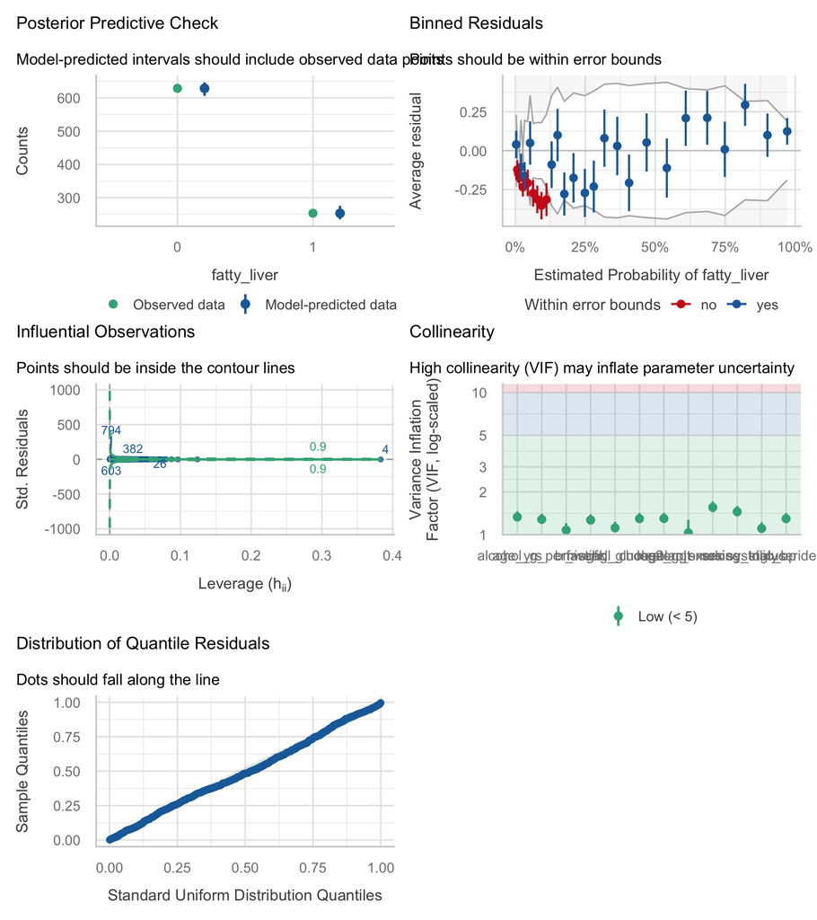

| Term | VIF | VIF_CI_low | VIF_CI_high | SE_factor | Tolerance | Tolerance_CI_low | Tolerance_CI_high |
| --- | --- | --- | --- | --- | --- | --- | --- |
| age_yrs | 1.332473 | 1.240384 | 1.459839 | 1.154328 | 0.7504844 | 0.6850072 | 0.8062016 |
| sex | 1.557640 | 1.436178 | 1.712926 | 1.248055 | 0.6419968 | 0.5837964 | 0.6962926 |
| bmi | 1.077561 | 1.029563 | 1.203484 | 1.038056 | 0.9280220 | 0.8309212 | 0.9712856 |
| systolic_bp | 1.106549 | 1.050971 | 1.222728 | 1.051926 | 0.9037109 | 0.8178431 | 0.9515015 |
| smoking_status | 1.451923 | 1.344013 | 1.593682 | 1.097706 | 0.6887418 | 0.6274779 | 0.7440403 |
| alcohol_g_per_week | 1.281558 | 1.196526 | 1.403381 | 1.132059 | 0.7803002 | 0.7125649 | 0.8357527 |
| regular_exercise | 1.032145 | 1.003766 | 1.274379 | 1.015945 | 0.9688564 | 0.7846962 | 0.9962482 |
| fasting_glucose | 1.117435 | 1.059434 | 1.232035 | 1.057088 | 0.8949070 | 0.8116651 | 0.9438999 |
| triglycerides | 1.296092 | 1.209017 | 1.419440 | 1.138460 | 0.7715503 | 0.7045030 | 0.8271181 |
| hdl_cholesterol | 1.296626 | 1.209477 | 1.420032 | 1.138695 | 0.7712324 | 0.7042096 | 0.8268037 |

[output cut: 2 more lines]

**Binned residuals are the check that fails.** Only 70% of binned residuals lie inside their error bounds, against a target of 95% or more, so the model is measurably miscalibrated somewhere across the fitted-probability range. With 253 events spread over 882 observations each bin holds around 29 participants, so the check is noisy, but the pattern is consistent with the linear-in-log-odds assumption failing for BMI: the BMI-steatosis relationship is steeper in the middle of the range than at either extreme, and a single linear term cannot capture that.

**Collinearity is not a problem in the reduced model.** The largest VIF is 1.56 (sex), well below the conventional threshold of 5. In the 18-predictor version the largest VIF is 24.7, so the a-priori cut is doing real work.

**There is no separation.** All coefficients are finite, the largest standard error on the log-odds scale is 0.31, and every level of every categorical predictor contains events (the smallest cell is 1 - female current smokers with fatty liver - which is thin but not empty). That cell is worth noting because it is where a student adding a `sex * smoking_status` interaction would run into trouble: with 16 female current smokers in total, the interaction contrast is estimated from almost nothing and its standard error explodes.

**Influence is unremarkable.** The largest Cook’s distance is 0.098 and the largest leverage 0.383; no single participant drives the fit.

Finally, a targeted check of the liver-enzyme decision. Adding ALT and AST back alongside gamma-GT does not produce alarming VIFs (largest 2.24), but it **reverses the sign of the gamma-GT coefficient**: GGT goes from OR 1.31 (95% CI 1.01 to 1.70) in the model above to OR 0.64 (95% CI 0.45 to 0.89) (p = 0.010) with the other two enzymes present, while ALT takes over as the enzyme of record (OR 1.09 (95% CI 1.06 to 1.13) per U/L, p <0.001). Three correlated markers of the same organ competing for the same variance is exactly the situation in which a conditional coefficient stops meaning what its name suggests, and it is the main reason only one enzyme is carried in the primary model.

# Discussion

**Limitations.** The design is cross-sectional, so temporal order is unknown and reverse causation is entirely plausible - a fatty liver raises GGT, so the GGT-steatosis association almost certainly runs partly backwards from outcome to “predictor”. The outcome is ultrasound-defined, which is operator-dependent, has limited sensitivity for mild steatosis and is degraded by obesity itself, so misclassification is probably differential with respect to BMI, the strongest predictor. Health-check attendees are self-selected and healthier than the general Japanese population, which compresses the range of every risk factor and will attenuate the odds ratios. Alcohol is self-reported in g/week with 284 attendees reporting exactly zero, and under-reporting by heavy drinkers is the standard failure mode - the protective alcohol coefficient should not be read as evidence that drinking prevents fatty liver. No medication data are available, so statins, antihypertensives and glucose-lowering drugs are unmeasured confounders. Waist circumference, insulin, HOMA-IR and viral hepatitis status are absent, and the first two are more direct measures of the visceral adiposity and insulin resistance that drive this condition than BMI is. The binned-residual check fails (70% inside bounds), indicating miscalibration that a non-linear term for BMI would probably improve. Complete-case analysis dropped 30 of 912 rows. All estimates are associations, not causal effects.

**Future work.** Refit with a spline or fractional polynomial for BMI to address the calibration failure, and add waist circumference and a fasting insulin measure so that the model separates visceral adiposity from body mass.

# Feasibility notes

*NOT part of a student report.*